# Lab 6 - La Quinta is Spanish for next to Denny’s, Pt. 1

Visualizing spatial data

Musab Isah

Student ID:

Load the needed packages. Note: dsbox is not yet on CRAN. For now, you need to install it before you load the library. Uncomment, by deleting # from, the two lines of code below.

```r
#install.packages("devtools")
#devtools::install_github("rstudio-education/dsbox")
```

Load the libraries here.

```r
library(tidyverse)
library(dsbox)
```

To help with our analysis we will also use a dataset on US states, which is located in your repository’s `data` folder.

```r
states <- read_csv("data/states.csv")
```

# Exercises

1. What are the dimensions of the Denny’s dataset? (Hint: Use inline R code and functions like `nrow` and `ncol` to compose your answer.) What does each row in the dataset represent? What are the variables?

```r
dim(dennys)
```

```
## [1] 1643    6
```

```r
#head(dennys)
```

2. What are the dimensions of the La Quinta’s dataset? What does each row in the dataset represent? What are the variables?

```r
dim(laquinta)
```

```
## [1] 909   6
```

```r
#head(laquinta)
```

Knit, *commit, and push your changes to GitHub with an appropriate commit message. Make sure to commit and push all changed files so that your Git pane is cleared up afterwards.*

3. Add a country variable to the Denny’s and Laquinta’s datasets and set all observations equal to `"United States"`. Remember, you can use the `mutate` function for adding a variable. Make sure to save the result of this as `dn` and lq, respectively, so that the stored data frame contains the new variable going forward.

```r
dn <- dennys %>%
    mutate(country = "United States")
```

```r
lq <- laquinta %>%
    mutate(country = "United States")
```

Knit, *commit, and push your changes to GitHub with an appropriate commit message. Make sure to commit and push all changed files so that your Git pane is cleared up afterwards.*

4. Which states have the most and fewest Denny’s locations? What about La Quinta? Is this surprising? Why or why not?

For Denny’s - Most

```r
dn %>%
    count(state) %>%
    arrange(desc(n))
```

```
## # A tibble: 51 x 2
##    state     n
##    <chr> <int>
##  1 CA      403
##  2 TX      200
##  3 FL      140
##  4 AZ       83
##  5 IL       56
##  6 NY       56
##  7 WA       49
##  8 OH       44
##  9 MO       42
## 10 PA       40
## # … with 41 more rows
```

For Denny’s - Fewest

```r
dn %>%
    count(state) %>%
    arrange((n))
```

```
## # A tibble: 51 x 2
##    state     n
##    <chr> <int>
##  1 DE        1
##  2 DC        2
##  3 VT        2
##  4 AK        3
##  5 IA        3
##  6 NH        3
##  7 SD        3
##  8 WV        3
##  9 LA        4
## 10 MT        4
## # … with 41 more rows
```

For La Quinta - Most

```r
lq %>%
    count(state) %>%
    arrange(desc(n))
```

```
## # A tibble: 59 x 2
##    state     n
##    <chr> <int>
##  1 TX      237
##  2 FL       74
##  3 CA       56
##  4 GA       41
##  5 TN       30
##  6 OK       29
##  7 LA       28
##  8 CO       27
##  9 NM       19
## 10 NY       19
## # … with 49 more rows
```

For La Quinta - Fewest

```r
lq %>%
    count(state) %>%
    arrange((n))
```

```
## # A tibble: 59 x 2
##    state     n
##    <chr> <int>
##  1 AG        1
##  2 ANT       1
##  3 BC        1
##  4 CH        1
##  5 FM        1
##  6 ME        1
##  7 ON        1
##  8 QR        1
##  9 SL        1
## 10 VE        1
## # … with 49 more rows
```

5. Which states have the most Denny’s locations per thousand square miles? What about La Quinta?

Joining Denny’s and states

```r
dn %>%
  count(state) %>%
  inner_join(states, by = c("state" = "abbreviation"))
```

```
## # A tibble: 51 x 4
##    state     n name                     area
##    <chr> <int> <chr>                   <dbl>
##  1 AK        3 Alaska               665384.
##  2 AL        7 Alabama               52420.
##  3 AR        9 Arkansas              53179.
##  4 AZ       83 Arizona              113990.
##  5 CA      403 California           163695.
##  6 CO       29 Colorado             104094.
##  7 CT       12 Connecticut            5543.
##  8 DC        2 District of Columbia     68.3
##  9 DE        1 Delaware               2489.
## 10 FL      140 Florida               65758.
## # … with 41 more rows
```

Joining La Quinta’s and states

```r
lq %>%
  count(state) %>%
  inner_join(states, by = c("state" = "abbreviation"))
```

```
## # A tibble: 48 x 4
##    state     n name           area
##    <chr> <int> <chr>         <dbl>
##  1 AK        2 Alaska      665384.
##  2 AL       16 Alabama      52420.
##  3 AR       13 Arkansas     53179.
##  4 AZ       18 Arizona     113990.
##  5 CA       56 California  163695.
##  6 CO       27 Colorado    104094.
##  7 CT        6 Connecticut   5543.
##  8 FL       74 Florida      65758.
##  9 GA       41 Georgia      59425.
## 10 IA        4 Iowa         56273.
## # … with 38 more rows
```

```r
dn <- dn %>%
  mutate(establishment = "Denny's")
lq <- lq %>%
  mutate(establishment = "La Quinta")
```

Since the two data frames have the same columns, we can easily bind them with the `bind_rows` function:

```r
dn_lq <- bind_rows(dn, lq)
```

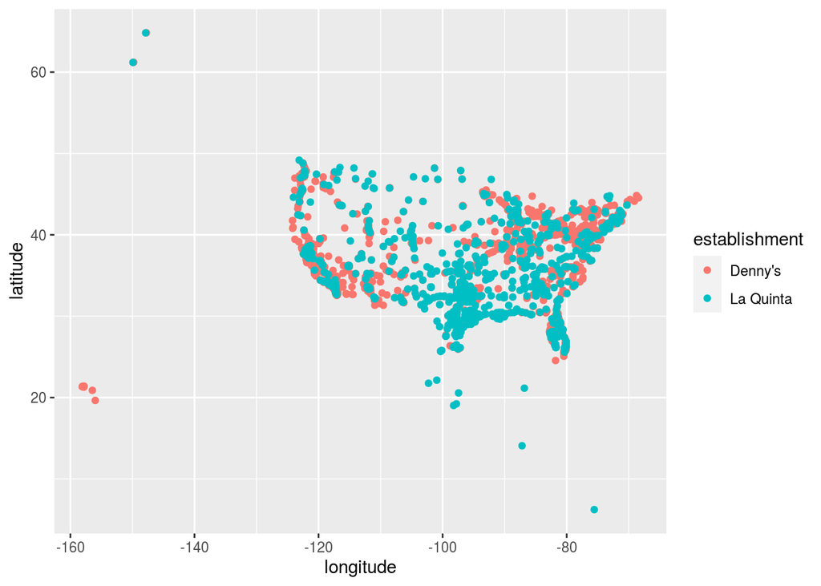

```r
ggplot(dn_lq, mapping = aes(x = longitude, y = latitude, color = establishment)) +
    geom_point()
```

Knit, *commit, and push your changes to GitHub with an appropriate commit message. Make sure to commit and push all changed files so that your Git pane is cleared up afterwards and review the md document on GitHub to make sure you’re happy with the final state of your work.*